# hydflood - Vignette

Arnd Weber

2025-02-27

# Purpose

**hydflood** is an R package designed to compute flood extent and duration along the German federal waterways Elbe and Rhine.

# Use

## Installation

The package **hydflood** is available from CRAN. To install it run:

```r
install.packages("hydflood")
```

To install the recent developmental version from Github execute the following commands:

```r
install.packages("devtools")
library(devtools)
devtools::install_github("bafg-bund/hydflood")
```

Afterwards **hydflood** can be loaded like every other R package with the following command:

```r
options("hydflood.datadir" = tempdir())
library(hydflood)
```

## Dependencies

The package **hydflood** is built around the packages [`terra`](https://cran.r-project.org/package=terra) and [`hyd1d`](https://hyd1d.bafg.de/). [`hyd1d`](https://hyd1d.bafg.de/) internally provides gauging data for all gauging stations along the rivers Rhine and Elbe operated by the German Waterway and Shipping Administration and computes 1D water levels. The package [`terra`](https://cran.r-project.org/package=terra) provides the S4 class `SpatRaster` and thereby enables the GIS based comparison between extrapolated water levels and elevation data.

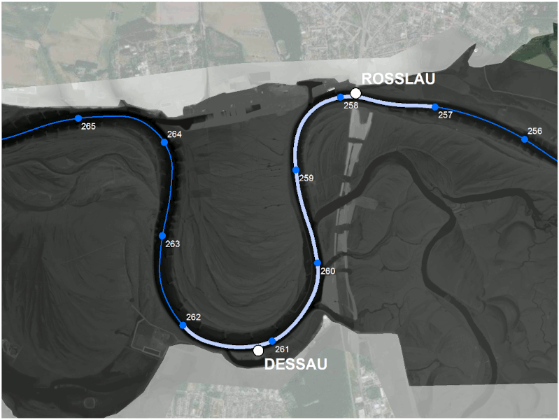

**Fig. 1**: Digital elevation model of the waterway (DEM-W, in German: Digitales Geländemodell des Wasserlaufs, DGM-W) with 1 m spatial resolution at the River Elbe near Rosslau and Dessau.

**hydflood** provides download facilities for the digital elevation models of the waterways Rhine and Elbe (DEM, Weber (2020)) with 1 m spatial resolution for chosen extents. If necessary, alternative `dem`’s can be supplied by users. They just need to overlap with active floodplains of either the Rhine ([`sf.afr`](https://hydflood.bafg.de/reference/sf.afr.html)) or the Elbe ([`sf.afe`](https://hydflood.bafg.de/reference/sf.afe.html)).

To create a water surface raster, which can be compared to the `dem`, a simple 1D to 2D conversion is applied to water level data computed along the river axis with the package [`hyd1d`](https://hyd1d.bafg.de/). Therefore so called cross section areas (`csa`) are needed. They originate from cross sections used for the SOBEK models run for and incorporated into [FLYS](https://www.bafg.de/DE/5_Informiert/1_Portale_Dienste/FLYS/flys_node.html).

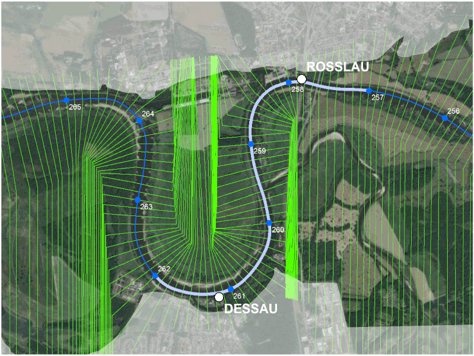

**Fig. 2**: Cross sections produced to gather input data for SOBEK models used in [FLYS](https://www.bafg.de/DE/5_Informiert/1_Portale_Dienste/FLYS/flys_node.html) at the River Elbe near Rosslau and Dessau.

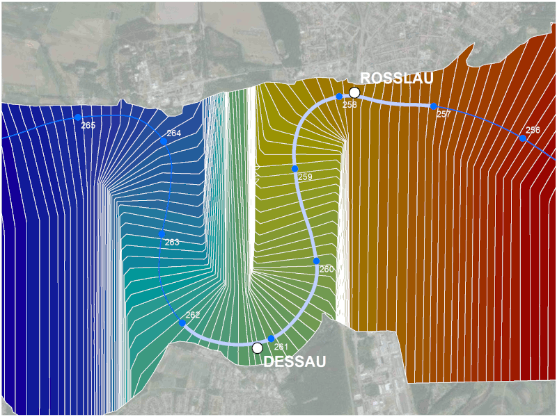

**Fig. 3**: Cross section areas derived from the cross sections illustrated in Fig. 2 at the River Elbe near Rosslau and Dessau.

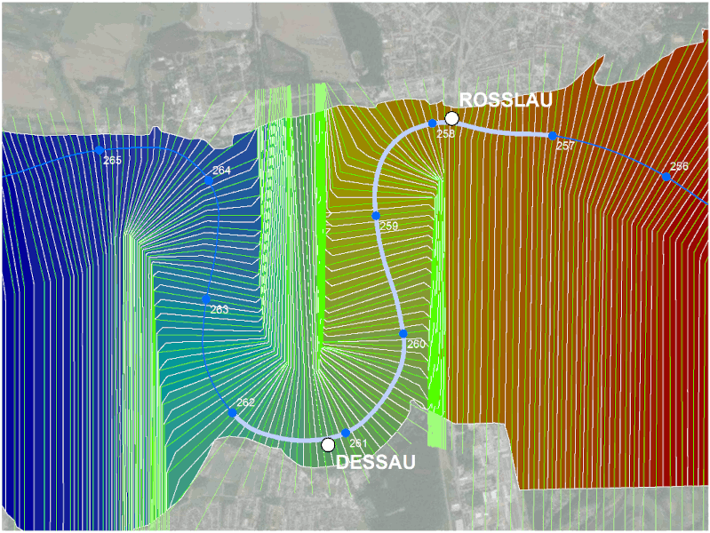

**Fig. 4**: Cross section areas illustrated in Fig. 3 overlaid by the corresponding cross sections illustrated in Fig. 2 at the River Elbe near Rosslau and Dessau.

These cross sections, one for each individual river station, represent water level isolines perpendicular to the rivers axis. To enable the spatial extrapolation of water level information for each river station, they were converted to cross section areas (`csa`) which are similar to stairs along the river axis, each step corresponding to a station of the 1D [`WaterLevelDataFrame`](https://hyd1d.bafg.de/reference/WaterLevelDataFrame-class.html) computed by the [`waterLevel`](https://hyd1d.bafg.de/reference/waterLevel.html) function of package [`hyd1d`](https://hyd1d.bafg.de/). To accelerate the computations, while keeping the package size on [CRAN](https://cran.r-project.org/) small, cross section areas are downloaded once for each river by package internal facilities during their first use.

## Computation of flood extents and durations

The actual computation of a flood extent in a selected computational domain for a given time can be split into five steps:

1. Extraction of relevant stations within the computational domain
2. Creation of a [`WaterLevelDataFrame`](https://hyd1d.bafg.de/reference/WaterLevelDataFrame-class.html) for the selected river section
3. Computation of the 1D water level using the [`waterLevel`](https://hyd1d.bafg.de/reference/waterLevel.html) function of package [`hyd1d`](https://hyd1d.bafg.de/)
4. Transfer of the 1D water level information from the [`WaterLevelDataFrame`](https://hyd1d.bafg.de/reference/WaterLevelDataFrame-class.html) to the cross section areas (`csa`) through the join field `station_int`
5. Computation of a binary flood raster `fd` through the equation `fd[csa > dem] = fd[csa > dem] + 1`

To compute flood durations these five steps are repeated for every given time step, so that the resulting raster contains counts of how often each individual raster cell was flooded. The possible range of values is between 0 and the number of time steps given.

## Usage

```r
# import the raster data and create a raster stack
x <- hydSpatRaster(filename_dem = "data-raw/raster.dem.tif",
                   filename_csa = "data-raw/raster.csa.tif")
```

After initialinzig an object of type `hydSpatRaster` everything else is straight forward. Create a temporal sequence `seq`:

```r
seq <- seq(as.Date("2016-12-01"), as.Date("2016-12-31"), by = "day")
```

And supply both of them to the `flood3` function, which will do the computation and return an ‘INT4S’ raster with counts of how often the individual cell of the `dem` was lower than the `csa` during the temporal sequence. For each time step of the temporal sequence the corresponding 1D `WaterLevelDataFrame` is computed, joined to `csa` through the `station_int` column and compared to the `dem` so that the possible values of the returned product range between 0 and `length(seq)`:

```r
# compute a flood duration
fd <- flood3(x = x, seq = seq)

# and plot it
plot(fd)
```

# Products

## ShinyApps

### flood3daily

The [`flood3`](https://hydflood.bafg.de/reference/flood3.html) function is the central function of the package **hydflood**. With the help of this function daily flood extents are computed for a number of areas along the River Elbe. These products are visualized through a shiny web application available through:

https://shiny.bafg.de/flood3daily/

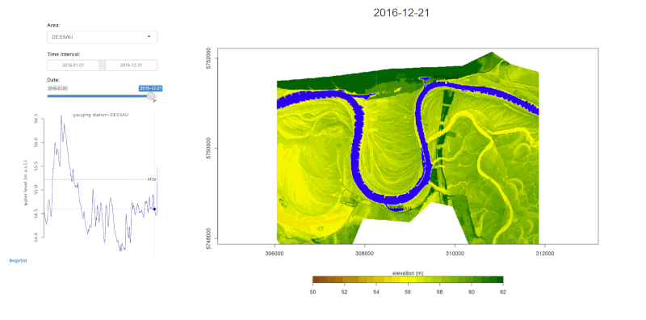

**Fig. 5**: Screenshot of the [flood3daily-ShinyApp](https://shiny.bafg.de/flood3daily/) with the modelled flood extent computed for 2016-12-21 at the River Elbe between Rosslau and Dessau, Germany.

### flood3wms

https://shiny.bafg.de/flood3wms/

[figure not shown]

**Fig. 6**: Screenshot of the [flood3wms-ShinyApp](https://shiny.bafg.de/flood3wms/) with the annual flood duration of 2016 at the River Elbe between Rosslau and Dessau, Germany.

# References

Weber, A. (2020). Digital elevation models of German waterway and navigation authorities - Version 0.1.0. BfG-Bericht, Bundesanstalt für Gewässerkunde, Koblenz, Germany: Bundesanstalt für Gewässerkunde, Koblenz, Germany. https://doi.org/10.5675/BfG-2011

Weber, A. (2022). Flood durations and potential natural vegetation distribution on the floodplains of River Rhine and River Elbe, Germany. data set, PANGAEA. https://doi.org/10.1594/PANGAEA.948042

Weber, A. (2023). Flood durations of the year 2022 on the floodplains of River Rhine and River Elbe, Germany. data set, PANGAEA. https://doi.org/10.1594/PANGAEA.961117

Weber, A. (2024). Flood durations of the year 2023 on the floodplains of River Rhine and River Elbe, Germany. data set, PANGAEA. https://doi.org/10.1594/PANGAEA.972421

Weber, A., & Hatz, M. (2025). hyd1d: 1d Water Level Interpolation along the Rivers Elbe and Rhine. https://hyd1d.bafg.de/index.html